# The AI Debate and Posit Assistant

Lecture 11b  
POLS 6394 · Thursday, November 5

## November 5: where we left off

Lecture 11a covered the tools, how models work and what they cost. Today picks up where it stopped.

Today’s route:

**First, discussion**

1. The research debate: what AI changes about research, and what it risks.
2. Rerunning AI-based results, checking an AI answer, and whether models have politics.

**Then, practice**

3. Meet **Posit Assistant**, the AI assistant built into RStudio, in five short steps on code you already know.
4. Last night’s election results: get them, check them, and plot them with Posit Assistant.
5. Lab: scrape a real page and compare it with 1995. It becomes Problem Set 6.

# The Debate Over AI in Research

## An economist writes a paper overnight

[figure not shown]

His asterisk on “I” is the debate in one character. Who wrote the paper, and how would you check it?

Paul Novosad (@paulnovosad), [thread on X](https://x.com/paulnovosad/status/2021638738376323171), February 11, 2026.

## Hall: what could researchers do with more capacity?

Hall describes using an agent to extend a vote-by-mail study, then commissioning an independent manual audit.

His proposal is broader than writing papers faster: research that keeps updating as new data arrive, and teams that can examine more questions.

What still needs people? Choosing the question, judging the design, and checking whether the result is right.

[Andrew Hall, The 100x Research Institution](https://freesystems.substack.com/p/the-100x-research-institution), January 13, 2026.

## A different question: how adoption happens

Narayanan and Kapoor distinguish improvements in models from their adoption in real organizations.

Better software doesn’t automatically supply usable data, change incentives, or decide who is responsible for a mistake.

How much of Hall’s proposal needs better models, and how much needs a different research institution?

Arvind Narayanan & Sayash Kapoor, [AI as Normal Technology](https://knightcolumbia.org/content/ai-as-normal-technology), April 15, 2025. Background for discussion; not an additional reading assignment today.

## Westwood: the paper as wrapping

[figure not shown]

Sean Westwood (@seanjwestwood), post on X, February 22, 2026.

## Kustov, Part I: the ground has already shifted

Ten theses, posted March 2, a week after Westwood’s post and on a similar theme. The main ones:

- AI agents can already do most research tasks in social science better than most professors.
- The 30-page paper and the journal system can’t absorb the coming flood of submissions.
- Critics hold AI to a standard human research doesn’t meet: fake citations, p-hacking and failed replications already exist.
- Much of the resistance is about protecting status.

Alexander Kustov, [Academics Need to Wake Up on AI](https://www.popularbydesign.org/p/academics-need-to-wake-up-on-ai), March 2, 2026.

## Just out: AI reviews beat expert peer reviews

[King and Worthington](https://gking.harvard.edu/peerless) compared AI and human reviews of the same 124 manuscripts. The 134 human reviews came from Harvard’s rapidPeer service: paid experts, carefully chosen, whose reviews authors and former editors rated unusually highly.

Claude Opus 4.8, at its maximum reasoning setting, reviewed each paper twice: once with only the reviewer instructions, and once with a purpose-built prompt and **web search** (12.4 searches per review on average). The results below use the second; the first did almost as well.

- An AI judge from another company (GPT-5.5) preferred the AI review in **every decided pair (132 of 132)**.
- Three former journal editors each judged the same 10 pairs, not told that one review was AI. They preferred it in **26 of 30** picks.
- **5.5%** of the AI reviews’ claims about the manuscript were judged incorrect, against **15.9%** for the human reviews. The AI reviews cited no fabricated sources.

Gary King & Steven Worthington, *AI Article Reviews Dominate Human Peer Reviews at Their Best: Evidence and Policy Choices*, working paper, October 28, 2026.

## Kustov, Parts II and III: what he concedes, what he keeps

**Part II** (March 4), after a large and hostile response:

- **Concedes:** his claims were mainly about quantitative work. Fieldwork, interviews and archives gain value. Losing skills is a real risk, especially for students.
- **Keeps:** current tools will force research workflows to change.

**Part III** (April 15) shifts from AI to research quality:

- Most research was low-quality before AI. AI made that visible.
- Judge research by its accuracy and whether the author stands behind it, not by its tools. Disclose AI use when hiding it would mislead readers.
- On teaching he’s more pessimistic. He plans in-person written and oral exams.

Alexander Kustov, [Part II](https://www.popularbydesign.org/p/academics-need-to-wake-up-on-ai-part), March 4, 2026; [Part III](https://www.popularbydesign.org/p/academics-need-to-wake-up-on-ai-part-4c6), April 15, 2026.

## Faster production and better research

Suppose an assistant lets you run a hundred more specifications.

That could expose a fragile finding. It could also give you a hundred chances to select the result you wanted.

## A risk: understanding less, and thinking alike

Messeri and Crockett warn that researchers can mistake fluent assistance for understanding.

King and Worthington find that AI reviews now beat expert human reviews. They still warn that researchers who brainstorm with AI, even with different models, end up with roughly the same conventional ideas. AI reviewers could push whole literatures the same way, and a few models from a few companies become a single point of failure. Human reviewers’ disagreement is partly a strength.

Lisa Messeri & M. J. Crockett, [Artificial intelligence and illusions of understanding in scientific research](https://doi.org/10.1038/s41586-024-07146-0), Nature (2024) · Gary King & Steven Worthington, [AI Article Reviews Dominate Human Peer Reviews at Their Best](https://gking.harvard.edu/peerless/), October 28, 2026. Background for discussion; not additional reading assignments today.

## Another risk: slop

**Slop** is content that is cheap to produce and poorly written or poorly conceived. AI makes a plausible-looking paper cheap; it doesn’t make a good question or a sound design cheap.

Peer review runs on volunteer time. A flood of weak submissions takes reviewers away from the good ones, and some bad work gets through.

It’s already happening. In October 2025, arXiv stopped accepting computer-science review and position papers that hadn’t passed peer review, after a flood of LLM-written surveys its volunteer moderators couldn’t keep up with.

For your project: what would a reviewer find in it that a quick AI draft wouldn’t have?

[arXiv blog: CS review and position papers](https://blog.arxiv.org/2025/10/31/attention-authors-updated-practice-for-review-articles-and-position-papers-in-arxiv-cs-category/) · [404 Media](https://www.404media.co/arxiv-changes-rules-after-getting-spammed-with-ai-generated-research-papers/)

## Research and training are different questions

**Training: the product is you**

- The answer already exists. What matters is the skill you keep after the course.
- Skill comes from doing the work: getting stuck, finding the bug, fixing it.
- Handing that step to AI skips the part that teaches.
- You can’t judge output you couldn’t have produced yourself.

**Research: the product is the finding**

- What matters is a result others can trust and build on.
- Readers ask whether it is correct, reproducible and disclosed, not who typed the code.
- A faster tool that’s reliable is a gain, as statistical software was.
- Privacy, validity and journal disclosure rules still apply.

So the same tool gets different rules. Part I banned AI so you would build the skills to supervise it. Part II allows it in your research work, and you remain responsible for the result.

## Discussion

# Can you rerun it?

## Cloud models: you can rerun, for a while

Name a **dated model version** in your code, such as `gpt-4o-2024-08-06`, and the provider serves that same version on every call. Months later you can still rerun it, even after newer models come out.

But providers retire old versions. OpenAI shut down `gpt-4.5-preview` on **July 14, 2025**; after that, no one could rerun code that called it.

So a hosted model is reproducible for a while, not forever. Record the exact version, and save its outputs while you can.

[OpenAI: API model shutdowns](https://developers.openai.com/api/docs/deprecations)

## Local models: you can keep them

An open model is a file you download. Once it’s on your computer, it’s yours to keep and rerun, even if the developer stops offering it.

## A rerun may still differ

Ask the same model the same question twice and you may get two different answers, even with a model you’ve kept.

A model picks each word with some randomness. Small differences in software or hardware can also change the result, so setting a random seed may not be enough.

**Temperature**, where a model offers it, sets how much randomness: lower means more predictable answers, higher means more variety. A low temperature doesn’t make an answer true, or guarantee the same answer twice.

For research, separate **rerunning the model** from **reproducing the analysis of saved model outputs**. The second should remain possible even when the first isn’t.

[PyTorch: limits of reproducibility across environments](https://docs.pytorch.org/docs/2.14/notes/randomness.html)

## What belongs in the replication files?

- Exact model/version, provider, and date of use
- Your prompts, the data you sent, and settings such as temperature
- Raw responses, including errors and retries
- Code that turns those responses into the paper’s results
- For a local model: the model file itself, or where to download it

Keep API keys out of the repository.

# Checking an AI Answer

## The task: turnout in 2024

**Turnout** is the share of eligible voters who voted. Here is a small made-up dataset:

| state | year | votes | eligible | population |
| --- | --- | --- | --- | --- |
| A | 2020 | 20 | 50 | 100 |
| B | 2020 | 60 | 200 | 400 |
| A | 2024 | 30 | 50 | 100 |
| B | 2024 | 80 | 200 | 400 |

You ask an assistant: *“For each state, calculate turnout in 2024: votes divided by eligible voters.”*

**First, work out one answer yourself.** In 2024, 30 of state A’s 50 eligible voters voted: 30 ÷ 50 = **0.6**.

## It runs, but it’s wrong

The assistant’s code:

```r
states |>
  filter(year == 2024) |>
  transmute(state, year, turnout = votes / population)
```

```
# A tibble: 2 × 3
  state  year turnout
  <chr> <dbl>   <dbl>
1 A      2024     0.3
2 B      2024     0.2
```

No error, a tidy table, two rows. But A shows 0.3, not the 0.6 you worked out. What went wrong?

It divided by `population`, which counts everyone, including children and noncitizens. One word fixes it: `votes / eligible` gives A 0.6 and B 0.4.

## It runs, and answers a different question

A second try. This time it divides by eligible voters:

```r
states |>
  filter(year == 2020) |>
  transmute(state, year, turnout = votes / eligible)
```

```
# A tibble: 2 × 3
  state  year turnout
  <chr> <dbl>   <dbl>
1 A      2020     0.4
2 B      2020     0.3
```

The formula is right, but the year isn’t: you asked for 2024.

## Know a few answers before you ask

Before you ask, have one or a few answers you already know to be true: worked out by hand, taken from a published source, or produced by code you trust.

Then see whether the AI reproduces them. You don’t need to check every number. If it misses a known answer, something is wrong.

Here, one known answer catches both mistakes. State A in 2024 should be 0.6. The wrong denominator gave 0.3, and the wrong year gave 0.4.

Rerunning doesn’t help: the wrong code gives 0.3 every time. Reproducible isn’t the same as right.

## Several known-answer checks make an eval

Checking one known answer is a spot check. Do it systematically and you have an eval.

An **eval** is a set of test prompts, each with an answer you know, plus a rule for scoring the AI’s answers. It’s how AI labs and companies measure models.

You’ll build one for Assignment 2: 10 to 20 test prompts from your own research area, scored against answers you know.

# Do models have politics?

## Political bias in LLMs: what users see

[Westwood, Grimmer, and Hall](https://modelslant.com/paper.pdf) asked people to judge political slant: 10,007 U.S. respondents compared answers from 24 models on 30 topics.

- Nearly all models were **perceived** as left-leaning, including by many Democrats.
- Asking for an ideologically neutral position made responses look more neutral.

Westwood, Grimmer & Hall, *Measuring Perceived Slant in Large Language Models Through User Evaluations*, working paper, May 8, 2025.

## What the slant study measures

- It measures **perceived slant**, not whether an answer is true. The authors chose value-laden topics and discuss that limitation.
- These were **spring 2025 model versions**, several generations old now. The study doesn’t establish how today’s versions behave.
- The respondents and topics were American. Results may differ elsewhere.

Prompt wording changed the ratings, which is another reason to report the prompts in your research.

## Where might a slant come from?

- **The training text.** Models learn from what people have written: news, Wikipedia, academic papers, online forums. The people who write most of it are more educated than the public, and in the U.S. more educated people lean left.
- **The tuning after training.** Companies then train models on human raters’ preferences and on their own written guidelines. Those decide what counts as a good, safe or balanced answer.
- **A thumb on the scale.** A company can also push a model on purpose, in either direction. Elon Musk has complained that xAI’s Grok is “too woke,” which he blamed on training it on the whole internet. In July 2025, Grok 4 was reported to look up Musk’s own posts before answering some contested questions.

These are possible explanations. The slant study doesn’t show which, if any, explains its results. The next slide shows a clearer case of the third: rules set by a government.

Grok 4 and Musk’s posts: [TechCrunch, July 10, 2025](https://techcrunch.com/2025/07/10/grok-4-seems-to-consult-elon-musk-to-answer-controversial-questions/).

## Political censorship: a comparison

[Pan and Xu](https://xu-xu.net/xuxu/llmcensorship.pdf) compared four models from China with five from outside it. They asked 145 political questions in Chinese, 100 times each.

| Models tested | Approximate refusal rates |
| --- | --- |
| From China | 10% to 60% |
| From outside China | 0% to 3% |

The models from China also gave shorter and more often wholly inaccurate answers. Differences were smaller on less-sensitive questions.

The topics are the familiar ones. Many models from China refuse to discuss the 1989 Tiananmen Square crackdown, deny or deflect questions about human rights abuses in Xinjiang and Hong Kong, and describe Taiwan only as “an inalienable part of China.”

Pan & Xu, [Political Censorship in Large Language Models Originating from China](https://doi.org/10.1093/pnasnexus/pgag013), *PNAS Nexus*. Specific models and versions, not all Chinese models.

# Meet Posit Assistant

## An assistant inside RStudio

**Posit Assistant** is an AI assistant built into RStudio 2026.04 and later. You chat with it in a pane next to your code.

Unlike web chat, it works on your actual project:

- It can read the files in your project; type `@` and a filename to point it at one.
- It knows which objects exist in your R session, by name and type. It sees their **values** only when it runs code to look.
- It can write code, run R code, and edit your files, asking first when an action is risky.

Today we turn those powers on one at a time, on code you already wrote by hand in Part I.

[RStudio User Guide: Posit Assistant](https://docs.posit.co/ide/user/ide/guide/tools/posit-ai.html) · [Posit Assistant documentation](https://assistant.posit.co/docs/getting-started/)

## Set it up

Skip the steps you finished Tuesday.

1. Click **Posit Assistant** on the RStudio toolbar. The first time, click **Install Posit Assistant**.
2. When it asks, click **Trust this workspace**, so it can work in your course project.
3. Click **Configure provider**, choose **OpenAI**, and supply the API key you stored Tuesday.
4. **Switch the model to GPT-6 Luna** in the model picker, and keep it all class.

It bills your OpenAI API credit by the token, at Luna’s $0.10 per million input tokens and $0.50 per million output. Your ChatGPT Plus subscription doesn’t cover it. Short questions cost a fraction of a cent; today’s whole class should cost a few cents.

## Where you type

Type in the **message box at the bottom of the Posit Assistant pane**:

[figure not shown]

Below the box, on the right: tokens used and cost so far, and the model picker. Make sure it says **GPT-6 Luna**.

To ask a question, just type it. A message that starts with `/` is a **command**: it switches the mode instead of going to the model. Send a command on its own, then your request as a second message.

## Modes: how much it may do

| Mode | How you get there | It may |
| --- | --- | --- |
| **Normal** | Where every chat starts. `/normal` brings you back from Ask. | Read, run code, and edit files. Safe actions run without asking; risky ones ask first. |
| **Ask** | `/ask`, or pick **Ask** in the mode picker | Read files and chat only. No code runs and no files change. |
| **Restricted** | `/restricted` turns it on; send it again to turn it off | Asks before **every** action, even reading a file. |

[Posit Assistant: Ask mode](https://assistant.posit.co/docs/features/ask-mode/) · [Permissions](https://assistant.posit.co/docs/features/permissions/)

## Ground rules for today

- **Never ask it about your API key.** RStudio blocks it from *reading* `.Renviron`, but code it runs could still print environment variables.
- **Approve actions *Once*.** Not *For this session* or *For this project*.
- **Don’t switch on `/yolo` or `/auto`.** They let it act without asking you.
- **Ask, read, check.** Every step below ends with a check you do yourself.

If the assistant won’t connect, follow my screen. The workbook has a sample answer for each step.

## Five steps, one new power each

| Step | New power | Your check |
| --- | --- | --- |
| 1. Explain | Reads your code | Trace one row yourself |
| 2. Inspect | Runs code to look at data | Compare with your own count |
| 3. Fix | Diagnoses an error | You run the fix |
| 4. Write | Writes new code | Check columns and one value |
| 5. Edit | Changes your file | Read the diff, then render |

Each step has a prompt in the workbook. Paste it exactly, so we can compare answers.

## Step 1: explain code you wrote

The workbook’s first chunk is the Problem Set 1 reshape: democracy scores for 96 countries in 9 years, from wide to long.

Run the chunk. Then paste this question into Posit Assistant:

```
Explain what the chunk lab11b-reshape in @11b-workbook.qmd does,
line by line, in plain language. Don't change anything.
```

**Your check** is on the next slide.

## Step 1: your check

**1. Albania in 1992, both ways.** Run the workbook chunk `lab11b-albania`:

```r
dem_wide |> filter(country == "Albania") |> select(country, `1992`)
```

```
# A tibble: 1 × 2
  country `1992`
  <chr>    <dbl>
1 Albania      5
```

```r
dem_long |> filter(country == "Albania", year == 1992)
```

```
# A tibble: 1 × 3
  country  year democracy_score
  <chr>   <int>           <dbl>
1 Albania  1992               5
```

The first line finds Albania’s row in the wide table and keeps its `1992` column. The backticks are needed because the name starts with a number.

The second finds the one Albania–1992 row in the long table. Both should say **5**.

**2. The row count.** The reshape chunk ends with `nrow(dem_long)`. It should print **864**: 96 countries × 9 year columns.

**3. Compare.** Did the explanation say each country-year becomes one row, and that `year` comes from the old column names?

## Step 2: let it look at the data

Run the workbook chunk that loads `cigarettes`. The assistant knows the object exists and its type, but not what’s inside.

Send `/restricted` on its own, so it asks before each action. (If you switched to Ask mode, send `/normal` first.) Then paste:

```
How many states and how many years are in the cigarettes data
frame in my R session? Run code to find out, and show me the code.
```

When it asks to run code, read the code, then click **Once**.

**Your check:** compare its answer with `n_distinct(cigarettes$state)` and `n_distinct(cigarettes$year)`, which you run yourself.

## Step 3: diagnose an error

The workbook’s next chunk has a mistake. Run it and copy the error, which ends:

```
! object 'packs' not found
```

Paste the prompt, adding the exact error:

```
This chunk in @11b-workbook.qmd (lab11b-broken) should compute
average packs per capita by year. It fails with the error below.
Explain the cause and propose the SMALLEST fix. Don't edit the file.

<paste the error>
```

**Your check:** make the fix yourself and run it. “Smallest fix” and “don’t edit” keep it from rewriting more than you asked.

## Step 4: write new code

A weak request leaves the model guessing:

```
Plot cigarette prices.
```

A strong request states the **goal**, the **context**, the **constraints** and the **output** you want:

```
Goal: a line chart of the average REAL price of cigarettes by year.
Context: the cigarettes data frame in my session; avgprs is the price
in cents and cpi is the consumer price index.
Constraints: ggplot2 only; don't change the data.
Output: one complete R chunk and one sentence on how you adjusted
for inflation.
```

**Your check:** paste its code into the workbook chunk and run it. Does it use `avgprs`, not `tax`? Does it divide by `cpi`? Compute 1995 yourself: about 120 (1982–84 cents).

## A wrong answer to step 4

Suppose the assistant had answered step 4 with this. It **runs without error**:

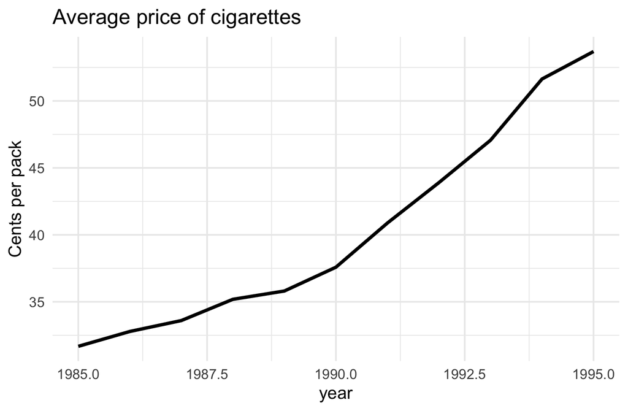

```r
library(tidyverse)
cigarettes <- read_csv("Data/cigarettes/cigarette.csv",
                       show_col_types = FALSE) |>
  select(-rownames)

cigarettes |>
  group_by(year) |>
  summarize(avg = mean(tax)) |>
  ggplot(aes(x = year, y = avg)) +
  geom_line(linewidth = 1) +
  labs(title = "Average price of cigarettes",
       y = "Cents per pack") +
  theme_minimal()
```

It runs, but it isn’t right and it isn’t what you asked. It plots the excise **tax**, not the price, and never adjusts for inflation. In 1995 the average tax (state, federal and local combined) was about 54 cents a pack; the average price was about $1.83.

## The checked version, and a title to check

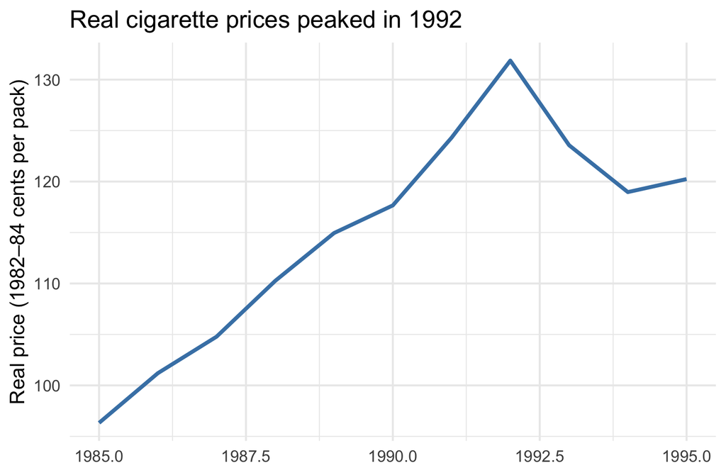

```r
cigarettes |>
  group_by(year) |>
  summarize(real_price = mean(avgprs / cpi)) |>
  ggplot(aes(x = year, y = real_price)) +
  geom_line(linewidth = 1, color = "steelblue") +
  labs(
    title = "Real cigarette prices peaked in 1992",
    x = NULL,
    y = "Real price (1982–84 cents per pack)"
  ) +
  theme_minimal()
```

An earlier draft of this slide was titled “Real cigarette prices rose steadily from 1985 to 1995.” The arithmetic was right, but the title wasn’t: prices rose to about 132 in 1992 and then fell to about 120. Check the words as well as the code.

## Step 5: let it edit your file

So far you copied code in yourself. Now the assistant edits the workbook directly.

1. **Commit first** in the Git pane, so you can see and undo every change.
2. Paste:

```
In @11b-workbook.qmd, in the chunk lab11b-real-price, add a title
that states what the chart shows. Change nothing else in the file.
```

3. Approve the edit **Once**.

**Your check:** open the diff in the Git pane. Did it change only that chunk? Is the title true of the chart? Then render.

## What you just practiced

- In step 1 it only explained; by step 5 it was editing your file. You approved each action that changed something.
- Each step ended with an answer you already knew or could find yourself: Albania’s score, a count, the 1995 price, the diff.
- The strong prompt in step 4 named the columns. The model couldn’t have known that `avgprs` is a price and `tax` is a tax, so you told it.

Optional extras: `/report` turns a chat into a Quarto document, `/context` shows how many tokens the chat has used, and `!r` runs a line of R without asking the model.

# Scraping with an assistant

## Scraping is delegation work now

- In Part I we skipped writing web scrapers by hand, on purpose.
- When a site has no API, you describe the page, the assistant writes the scraper, and you check the result.
- You don’t need to *write* `rvest` code fluently. You need to *read* it well enough to check it.
- The hard part was never the code. It’s knowing what the page actually says.

## `rvest` in three functions

```r
library(rvest)
page <- minimal_html('
  <table class="wikitable">
    <tr><th>Tax per pack</th><th>State</th></tr>
    <tr><td>$5.35</td><td>New York</td></tr>
    <tr><td>$1.41</td><td>Texas</td></tr>
  </table>')

page |> html_elements("th") |> html_text2()         # select elements, get their text
```

```
[1] "Tax per pack" "State"
```

```r
page |> html_element(".wikitable") |> html_table()  # a <table> becomes a tibble
```

```
# A tibble: 2 × 2
  `Tax per pack` State
  <chr>          <chr>
1 $5.35          New York
2 $1.41          Texas
```

```r
parse_number("$5.35")                                # text with "$" becomes a number
```

```
[1] 5.35
```

`read_html("file.html")` reads a saved page the same way. In a scraper, check the **selector** first (`"th"`, `".wikitable"`): a wrong one grabs the wrong part of the page.

## Reading the practice page

| Code | What it does |
| --- | --- |
| `library(rvest)` | Loads the scraping package |
| `minimal_html('...')` | Builds a tiny practice page from text. For a real page you’d use `read_html("file.html")` |
| `<table>` `<tr>` `<th>` `<td>` | HTML tags: a table, a row, a header cell, an ordinary cell |
| `class="wikitable"` | A label on the table. In a selector, the dot in `".wikitable"` means “with this class” |

A selector names what to grab: a tag (`"th"`), a class (`".wikitable"`), or both (`"table.wikitable"`).

## What each function does

| Code | What it does |
| --- | --- |
| `html_elements("th")` | Finds **every** `<th>` on the page |
| `html_text2()` | Keeps just the text you’d see |
| `html_element(".wikitable")` | Finds the **first** element with that class (no *s*: one, not all) |
| `html_table()` | Turns a `<table>` into a tibble, one column per header cell |
| `parse_number("$5.35")` | Drops the `$` and returns the number 5.35. It comes from readr, part of the tidyverse |

## Real pages are messier

Today’s page is Wikipedia’s [Cigarette taxes in the United States](https://en.wikipedia.org/wiki/Cigarette_taxes_in_the_United_States). It has **ten** HTML tables:

- The first is a “Part of a series on Taxation” sidebar. Code that takes “the first table” gets that.
- One lists cigarette taxes for 50 states plus DC.
- Another, right below it, lists **vape** taxes for the same 51 rows.

None of this is labeled as a trap. It’s an ordinary page.

## Save the page you scraped

Pages change. This one was last edited October 26, 2026, and the numbers will move as states change their taxes.

- **Scrape once, save the HTML,** and work from the saved copy. The lab uses `Labs/w11/cigarette-taxes-wikipedia-2026-10-26.html`, which we saved for you.
- To save one yourself: in the browser, **File → Save Page As**, format **Webpage, HTML Only**. Or in R, `download.file(url, "page.html")` copies the page at the address `url` into the file `page.html`.
- Record the address and the date, as you would a model version.
- Use an API when one exists. Otherwise go gently: don’t hammer a site with repeated requests, and check its terms.

## Check the result against the page

The scraper’s output is a claim about the page. Before you ask, read a few answers off the page yourself:

- **The row count:** count the rows in the state table. Is DC one of them?
- **A few values:** read two or three states’ taxes straight off the page.
- **The units:** what does the column header say the numbers are in?

If the scraper reproduces those, it found the right table. If it doesn’t, you know before you build on it. Task 1 of the lab has you write these down before the assistant writes any code.

# Last night’s votes

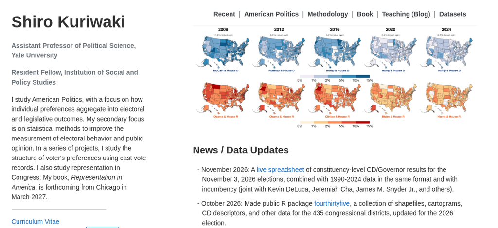

Shiro Kuriwaki (Yale) and his coauthors are filling it in as the results come in.

[shirokuriwaki.com](https://www.shirokuriwaki.com/)

The team is entering the 2026 results by hand from NYT and NBC reporting, in a public Google Sheet.

- **2026_by-contest:** one row per House, Senate or governor race, with total votes, the Democratic share of the two-party vote, and whether the race has been called.
- **2026_by-state:** state totals, ending in a **TOTAL** row.
- **2026_by-cand:** one row per candidate.

The results are unofficial and still being counted. Our slides use a copy taken this morning; the live sheet may have changed since.

Cha, DeLuca, Kuriwaki & Snyder, [Candidates in American General Elections, 2026 version](https://docs.google.com/spreadsheets/d/1otML47xPsa9Wf1A_XEISLJFHEm6wpv5D3FzRe2-xZXY/edit). Archived 2006–2024 data: [Harvard Dataverse](https://doi.org/10.7910/DVN/DGDRDT).

## Step 1: get the data

```
Use googlesheets4 to read the 2026_by-contest and 2026_by-state tabs
of this Google Sheet into R, as data frames called contests and
by_state. The sheet is public, so no Google login is needed.
Show me the code.
https://docs.google.com/spreadsheets/d/1otML47xPsa9Wf1A_XEISLJFHEm6wpv5D3FzRe2-xZXY/edit
```

`googlesheets4` reads Google Sheets into R; it’s in the course package list. Its `gs4_deauth()` skips the Google login for a public sheet. You haven’t used it before. The assistant has, and it shows you the code.

**Your check:** `contests` should have one row per race. The House has 435 seats, so there should be 435 House rows.

## Step 2: a question with a known answer

```
How many House races have been called so far? Use by_state.
```

Before you ask, look at the last row of the by-state tab. Its **TOTAL** row already says how many House races have been called:

```r
by_state |> filter(state == "TOTAL") |> select(state, H_called_winners, n_CDs)
```

```
# A tibble: 1 × 3
  state H_called_winners n_CDs
  <chr>            <dbl> <dbl>
1 TOTAL              394   435
```

If the code adds up the whole column, it counts every state twice, the TOTAL row included:

```r
sum(by_state$H_called_winners)
```

```
[1] 788
```

## Step 3: ask for a plot

```
Using contests, plot each House race's Democratic share of the two-party
vote against its Cook PVI. Convert PVI to a number first, with D+
positive and R+ negative. Keep races with both a Democrat and a
Republican and at least 90% of the vote counted. Add a dashed line
where share = 0.5 + PVI / 100.
```

The **Cook PVI** says how much more Democratic (D+) or Republican (R+) a district voted than the country as a whole in recent presidential elections. The dashed line is what that lean alone would predict in an evenly split year.

**Your check:** find one race yourself. Texas’s 28th district (Laredo) is R+3, and Democrats got 0.689 of the two-party vote. Its point should sit well above the line, at about (−3, 0.69).

## What the plot shows

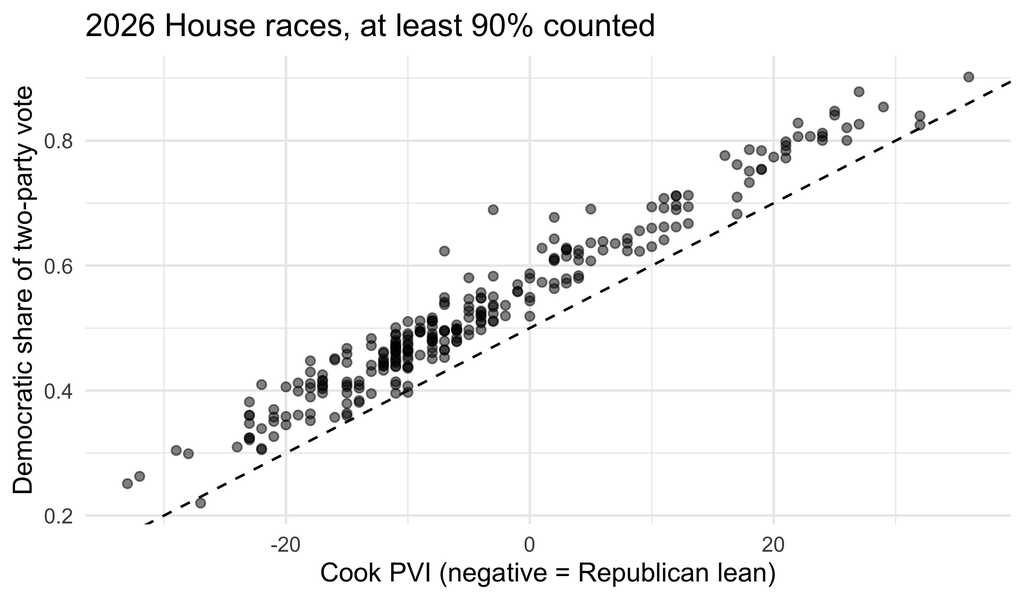

Most points sit above the line: Democrats ran ahead of their districts’ usual lean. This version was made from this morning’s copy; yours, from the live sheet, may differ a little.

# Lab

## Project checkpoint: one real result

Your next project checkpoint is due **Monday, November 9 at 7:00 PM**: your current pipeline runs from start to finish on your own materials and produces **one real result or an approved equivalent**.

That way you bring working code, not an empty repository, to the agentic project session the week of November 16.

## Lab: then and now

*Started in class; finish it as Problem Set 6, in `Psets/pset-06/pset-06.qmd`.*

The question: **which states raised their cigarette tax most between 1995 and today?**

0. **Run the setup chunk** at the top of the workbook if you restarted R. It loads `rvest` and the `cigarettes` data.
1. **Read the page yourself.** In the Files pane, open `Labs/w11/`, click the saved page and choose **View in Web Browser**. Find the table under *Cigarette tax rates by jurisdiction*, and note a few answers.
2. **Scrape it.** Commit first. Ask Posit Assistant for a scraper of the saved file, then run the check chunk and compare with the page.
3. **Compare with 1995.** Ask it to join today’s taxes to the 1995 taxes in the `cigarettes` data from steps 2–4, then run the check chunk.
4. **Write the memo** in the workbook.

The prompts and check chunks are in `Psets/pset-06/pset-06.qmd`.

## Each assistant task: five moves

1. **Copy** the prompt from the grey box in the workbook (the lines inside it).
2. **Paste** it into Posit Assistant’s message box and press Enter.
3. **Read** the reply. Decline any request to edit a file; the prompt asks for code in the chat. If it asks to run code, read the code, then click **Once**.
4. **Paste its code** into the empty chunk below the prompt and delete the `#| eval: false` line, which stops a chunk from running.
5. **Run** that chunk, then the check chunk under it, and compare with what you know.

An error? Copy it from the Console into Posit Assistant, ask for a fix, and run the new version.

## Lab: what to check in the comparison

Joining two sources is where quiet errors live. Before you believe the ranking:

- **Keys:** the cigarette data uses state codes (`NY`); Wikipedia uses names. Did every state match? Which ones are missing, and why?
- **Units:** the 1995 `tax` is in cents; Wikipedia is in dollars.
- **What’s being measured:** the 1995 `tax` includes the federal tax (24¢ in 1995) and average local taxes. Wikipedia lists the state tax only. The codebook is in the workbook.
- **A sanity check:** Missouri’s tax has been 17¢ a pack since 1993. Does your comparison say it changed?

If the assistant handled all of this, your job is to show how you know.

## Lab: the critique memo

- The workbook ends with a short memo: what you asked, what the assistant got wrong (if anything), how you checked each point, and what you fixed.
- The memo is what’s graded, not the code.
- Commit and push when you’re done.

## Before Next Class

- **Problem Set 6** is released Tuesday, November 10 and due **Tuesday, November 17 at 10:00 AM**: the then-and-now lab and critique memo.
- **Project checkpoint (first real result)**, moved from today, is due **Monday, November 9 at 7:00 PM**.
- **Codex starts Tuesday:** two sessions next week, then the agentic project session the week of November 16. Check that `codex` starts in the terminal app you set up Tuesday (Ghostty on a Mac, Windows Terminal on Windows).
- Bring a real, small task from your own research that you’d hand to a coding assistant. Git is the safety net while we watch the agent work.